[O’Hara on GitHub](https://github.com/oharac)

# Process Commercial and Artisanal Fisheries stressors

Compiled on Mon Sep 18 09:54:37 2023 by ohara

```r
knitr::opts_chunk$set(fig.width = 6, fig.height = 4, message = FALSE, warning = FALSE)
library(terra)
library(oharac)
library(data.table)
library(tidyverse)
library(here)
source(here('common_fxns.R'))
```

This script is a modification to Jamie Afflerbach’s script for the Recent Pace of Change project (Halpern et al. 2019), original scripts can be found in https://github.com/OHI-Science/impact_acceleration/tree/master/stressors.

This script combines spatial catch data from [Watson (2017)](https://www.nature.com/articles/sdata201739) with species & gear specific categories defined in [`watson_gear_matching`](https://github.com/OHI-Science/impact_acceleration/blob/master/stressors/comm_fish/watson_gear_matching.Rmd) to create catch rasters for commercial fishing stressors.

# Summary

- Raw catch data is combined with `watson_gear_taxa_assignment.csv` as defined in `3a_fishing_stressors_gear_tyopes.Rmd`
- Data is summarized by catch type for the combined years 2015-2017, rasterized to half degree cells, and saved as a GeoTIFF.

# Methods

## Load Data

Load raw catch data and the dataset matching gear and taxon to the five stressor categories.

```r
watson_dir <- here_anx('../../git-annex/globalprep/_raw_data',
                       'IMAS_GlobalFisheriesLandings/d2020')

w_codes_xlsx <- file.path(watson_dir, 'Codes_raw.xlsx')
# codes_sheets <- readxl::excel_sheets(codes_xlsx)
w_cell_df <- readxl::read_excel(w_codes_xlsx, sheet = 'Cell') %>%
  janitor::clean_names() %>%
  select(-c(x5:x7))

w_gear_df <- readxl::read_excel(w_codes_xlsx, sheet = 'Gear') %>%
  janitor::clean_names() %>%
  select(-c(x9:x10))
w_gear_clean <- w_gear_df %>%
  select(fleet_gear_name, f_gear_code) %>%
  distinct() %>%
  mutate(across(where(is.character), tolower))

w_taxa_df <- readxl::read_excel(w_codes_xlsx, sheet = 'Taxa') %>%
  janitor::clean_names() %>%
  select(-c(x8:taxonkey_11), taxonkey = taxonkey_1) %>%
  mutate(across(where(is.character), tolower))

gear_taxa <- read_csv(here('int/watson_gear_taxa_assignment.csv')) %>%
  mutate(hb  = (bycatch == 'high'),
         pel = (type == 'pelagic'),
         dest = (destruction == 'destructive')) %>%
  mutate(catch_type = case_when(hb & pel  ~ 'pel_hb',
                                !hb & pel ~ 'pel_lb',
                                hb & !pel & !dest  ~ 'dem_nondest_hb',
                                !hb & !pel & !dest ~ 'dem_nondest_lb',
                                !pel & dest ~ 'dem_dest')) %>%
  select(taxon_name, common_name, fleet_gear_name, catch_type) %>%
  distinct()
```

## Wrangle catch data by catch type

The raw data includes catch for 2015-2017. Summarize the mean catch per cell per catch type, including artisanal, and save out.

```r
cell_catch_file <- here_anx('stressors/fishing_by_gear/watson_catch_by_cell_and_type.csv')

if(!file.exists(cell_catch_file)) {
  message('Loading catch df and binding to gear, taxon, catch_type df...')
  w_catch_df <- readRDS(file.path(watson_dir, 'Catch2015_2019.rds')) %>%
    janitor::clean_names() %>%
    oharac::dt_join(w_gear_clean, by = c('f_gear_code'), type = 'left') %>%
    oharac::dt_join(w_taxa_df, by = 'taxonkey', type = 'left') %>%
    oharac::dt_join(w_cell_df, by = 'cell', type = 'left') %>%
    oharac::dt_join(gear_taxa, by = c('taxon_name', 'common_name', 'fleet_gear_name'),
                    type = 'left') %>%
    select(year = i_year, cell_id = cell, area_km2 = ocean_areasqkm,
           ends_with('ind'), catch_type)

  message('Summarizing commercial catch types...')
  comm_catch_by_type_df <- w_catch_df %>%
    data.table() %>%
    .[ , .(tot_catch_cell = sum(reported_ind + iuuind + discards_ind)),
       by = .(cell_id, catch_type, area_km2)] %>%
    mutate(tot_catch_km2 = tot_catch_cell / (3 * area_km2))
  ### the 3 * area_km2 is because we're summing over three years of catch data...

  message('Summarizing artisanal catch type...')
  art_catch_df <- w_catch_df %>%
    data.table() %>%
    .[ , .(tot_catch_cell = sum(reported_nind + iuunind + discards_nind)),
       by = .(cell_id, area_km2)] %>%
    mutate(tot_catch_km2 = tot_catch_cell / (3 * area_km2),
           catch_type = 'artisanal')

  cell_catch_df <- bind_rows(comm_catch_by_type_df, art_catch_df)

  write_csv(cell_catch_df, cell_catch_file)
}
```

## Map total catch values by catch type

Cell values match LOICZID values from AquaMaps. Apply catch values to HCAF raster; reproject to bc 1 km resolution. Check for coastal gaps due to mismatch between Watson data and coastline data, and gapfill these to approximate Jamie’s gapfilling methods from RPoC. Note, some missing coastline values will be legit non-fished areas; if we use a focal() style window of one or two cells this shouldn’t distort values too much. Note that Jamie’s analysis seems to have gapfilled at a larger resolution (22.5 km x 22.5 km?), based on half-degree cells reprojected without setting resolution; here we reproject directly to the 1 km analysis resolution.

- Project catch to bc 1 km x 1 km
- Gapfill missing cells using `focal()` with a 11x11 window (Jamie’s method used a 22.5 km radius; here we’ll just do 5 km), then mask this to just coastal cells and add back to the unfilled data.

```r
gapfill_to_coast <- function(r) {
  coast_bc <- rast(here('_spatial/coastal_3nmi_buffer_bc_1km.tif'))
  ocean_bc <- rast(here('_spatial/ocean_bc_1km.tif'))

  r_gf_coast <- r %>%
    focal(w = 11, fun = mean, na.rm = TRUE, na.policy = 'only') %>%
    mask(coast_bc)

  df <- data.frame(x = as.vector(values(r)),
                   y = as.vector(values(r_gf_coast))) %>%
    mutate(z = ifelse(is.na(x), y, x),
           z = ifelse(is.na(z), 0, z))

  r_out <- r %>%
    setValues(df$z) %>%
    mask(ocean_bc)

  return(r_out)
}
```

```r
cell_catch_df <- read_csv(cell_catch_file)
ocean_bc <- rast(here('_spatial/ocean_bc_1km.tif'))

catch_type_vec <- cell_catch_df$catch_type %>% unique() %>% sort()

outf_stem <- here_anx('stressors/fishing_by_gear/fishing_catch_%s.tif')
for(ct in catch_type_vec) { ### ct <- catch_type_vec[1]

  outf <- sprintf(outf_stem, ct)
  if(file.exists(outf)) {
    message('Total catch map for ', ct, ' already exists... skipping!')
    next()
  }

  message('Processing total catch map for ', ct, ' fishing...')
  catch_type_df <- cell_catch_df %>%
    filter(catch_type == ct)

  hcaf_r <- rast(xmin = -180, xmax = +180, ymin = -90, ymax = +90,
                 resolution = 0.5, crs = '+init=epsg:4326') %>%
    setValues(1:ncell(.))

  catch_hcaf <- subst(hcaf_r,
                      from = catch_type_df$cell_id,
                      to = catch_type_df$tot_catch_km2,
                      others = NA)

  catch_bc <- project(catch_hcaf, ocean_bc, method = 'near')

  catch_bc_gf <- gapfill_to_coast(catch_bc)

  writeRaster(catch_bc_gf, outf, overwrite = TRUE)
}
```

### Plot catch intensity (tonnes per km<sup>2</sup>)

[figure not shown]

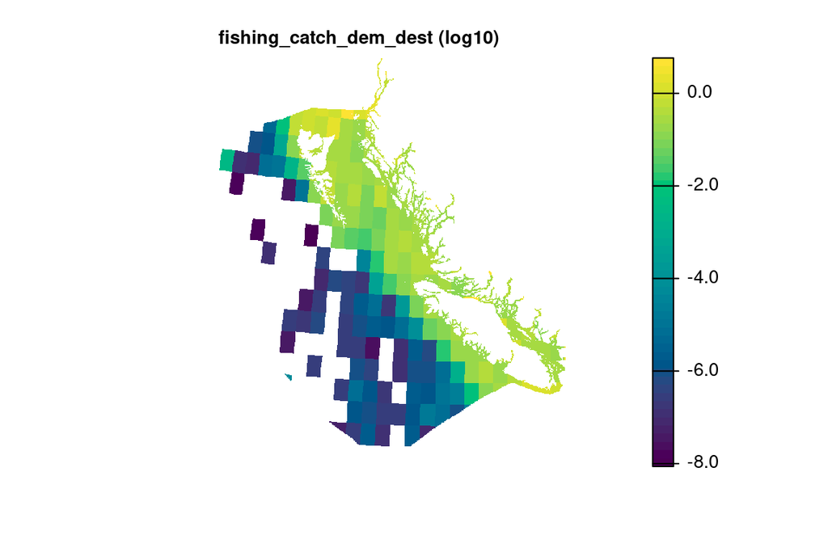

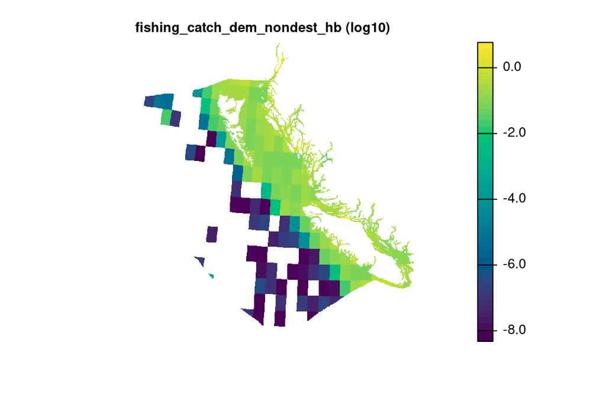

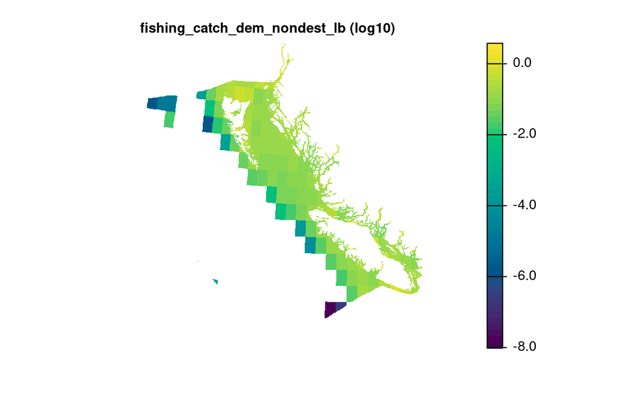

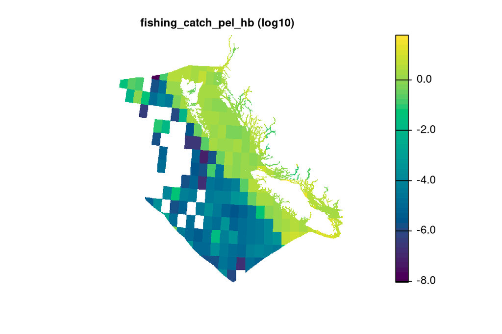

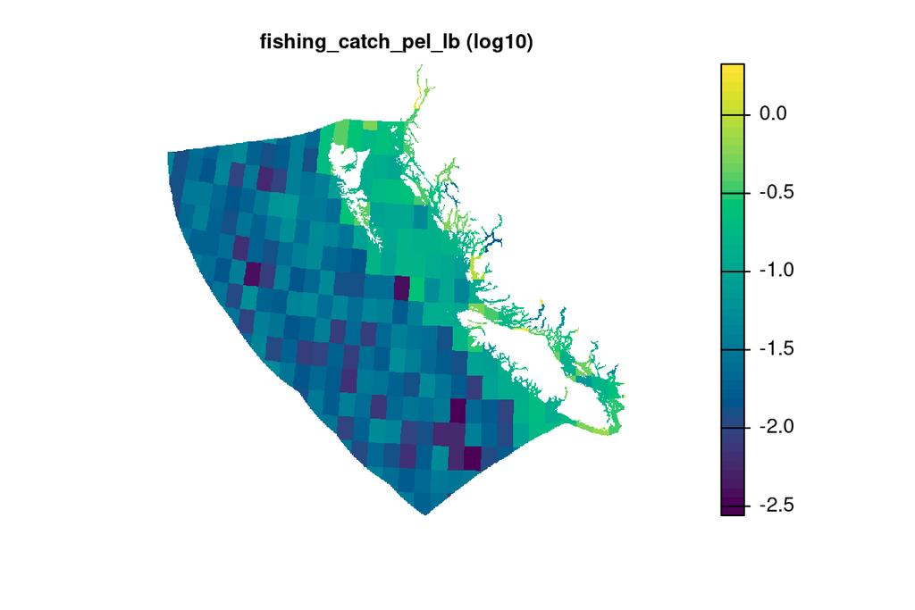

```r
catch_map_fs <- list.files(dirname(outf_stem), pattern = 'fishing_catch_.+.tif',
                           full.names = TRUE)
### check values:
# tot_catch1 <- sum(cell_catch_df$tot_catch_cell) / 3 ### avg over 3 years
# tot_catch_map <- rast(catch_map_fs) * ocean_bc * 100 %>% sum(na.rm = TRUE)
# tot_catch2 <- sum(values(tot_catch_map), na.rm = TRUE)
### 124.6e6 vs. 119.1e6, 5% difference...

for(f in catch_map_fs) { ### f <- catch_map_fs[1]
  r <- rast(f)

  plot(log10(r), col = hcl.colors(n = 50), axes = FALSE,
       main = basename(f) %>% str_replace('.tif', ' (log10)'))
}
```

## Normalize by NPP

Two NPP layers were created for bycatch and biomass removal stressors for species CHI methods (see script `_setup/3_process_fishing_bycatch.Rmd`), and are located:

- `here_anx('stressors/npp/log_npp_present_surf_gf_bc.tif')`
- `here_anx('stressors/npp/log_npp_present_benth_gf_bc.tif')`

Use surface for pelagics/artisanal and benthic for demersal.

```r
pel_log_npp <- rast(here_anx('stressors/npp/log_npp_present_surf_gf_bc.tif'))
dem_log_npp <- rast(here_anx('stressors/npp/log_npp_present_benth_gf_bc.tif'))

catch_map_fs <- list.files(dirname(outf_stem), pattern = 'fishing_catch_.+.tif',
                           full.names = TRUE)

for(f in catch_map_fs) { ### f <- catch_map_fs[1]

  f_out <- str_replace(f, 'fishing_catch_', 'fishing_npp_catch_')
  if(file.exists(f_out)) {
    message('Normalized catch layer ', basename(f_out), ' exists... skipping!')
    next()
  }

  if(str_detect(basename(f), 'dem_')) {
    message('Using demersal NPP for ', basename(f), '...')
    npp_r <- dem_log_npp
  } else {
    message('Using pelagic NPP for ', basename(f), '...')
    npp_r <- pel_log_npp
  }
  r_out <- rast(f) / npp_r
  writeRaster(r_out, f_out)
}
```

### Plot NPP-normalized catch intensity (tonnes per km<sup>2</sup> per log NPP)

[figure not shown]

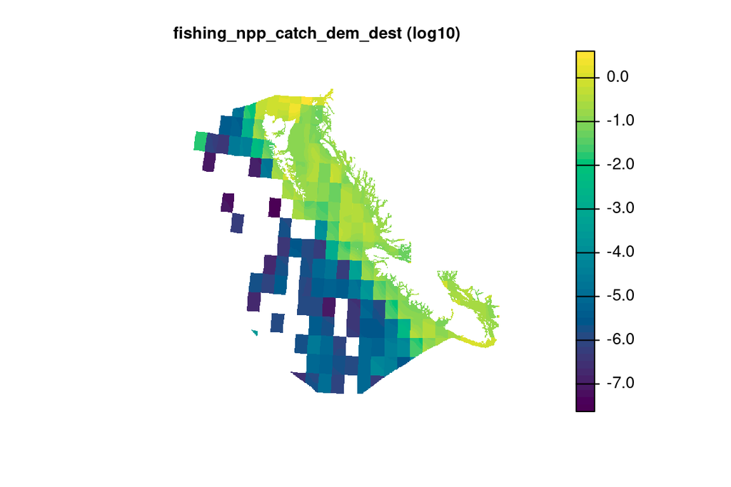

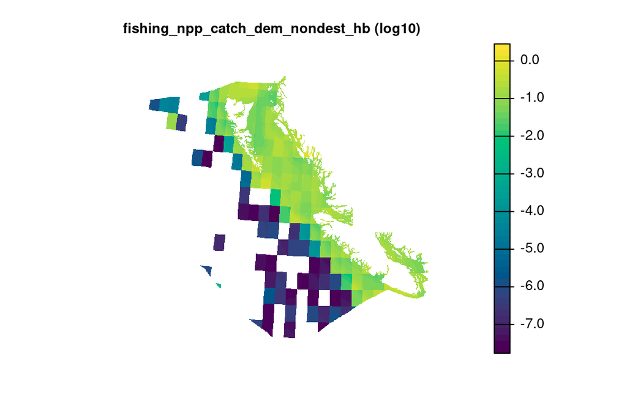

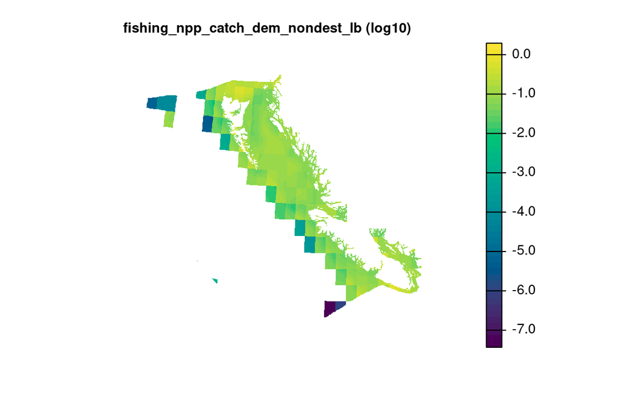

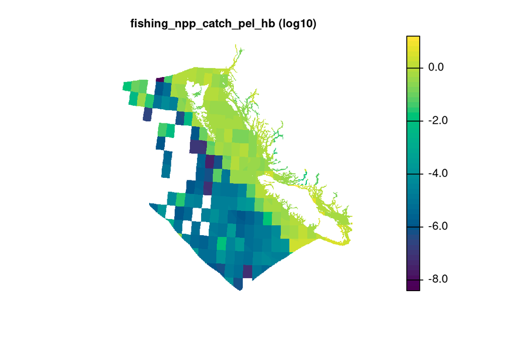

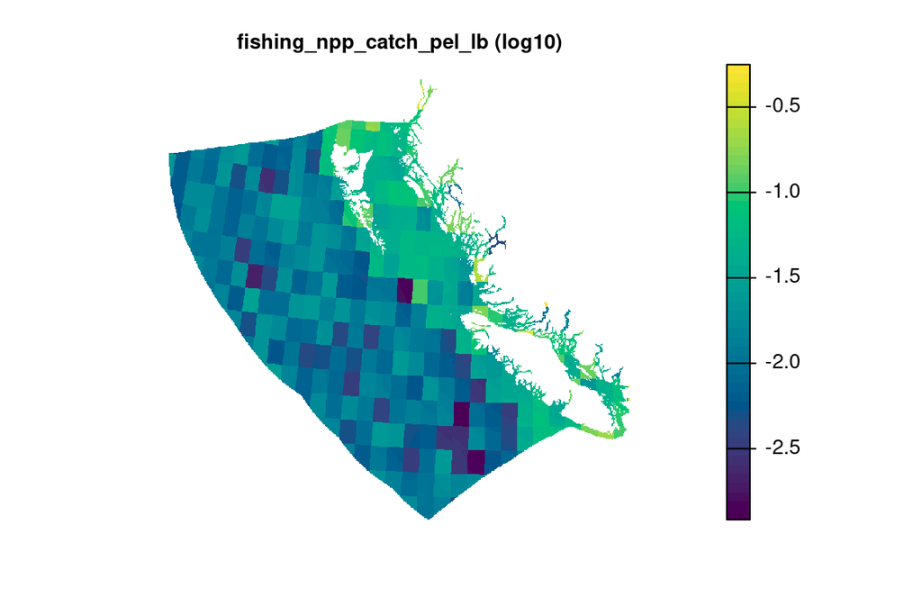

```r
npp_catch_map_fs <- list.files(dirname(outf_stem), pattern = 'fishing_npp_catch_.+.tif',
                           full.names = TRUE)

for(f in npp_catch_map_fs) { ### f <- npp_catch_map_fs[1]
  r <- rast(f)

  plot(log10(r), col = hcl.colors(n = 50), axes = FALSE,
       main = basename(f) %>% str_replace('.tif', ' (log10)'))
}
```

## Normalize and save out stressor layers

For the RPoC project, each layer was normalized by the 99.99%ile across all years for that catch type. Here, our cell resolution is 11x larger (121x in area), but visual comparison makes it look like 99.99%ile results in the best approximation to the RPoC maps.

```r
npp_catch_map_fs <- list.files(dirname(outf_stem), pattern = 'fishing_npp_catch_.+.tif',
                           full.names = TRUE)

### initialize a blank dataframe for reference points...
ref_df <- data.frame()


for(f in npp_catch_map_fs) { ### f <- npp_catch_map_fs[4]
  f_out <- here('_data/chi_halpern_2019/fishing_updated',
                str_replace(basename(f), '.+catch_', 'fishing_'))
  r <- rast(f)
  qtiles <- quantile(values(r) %>% na.omit(), c(.99, .999, .9999))
  qtile_df <- data.frame(catch_type = str_remove(basename(f_out), '.tif'),
                         qtile_cut = names(qtiles),
                         qtile_val = qtiles)
  ref_df <- bind_rows(ref_df, qtile_df)

  r_resc <- r / qtiles['99.99%']
  r_resc[r_resc > 1] <- 1
  writeRaster(r_resc, f_out, overwrite = TRUE)
}
write_csv(ref_df, here('_data/chi_halpern_2019/fishing_updated/ref_points.csv'))
```

### Plot normalized fishing pressure (0-1)

[figure not shown]

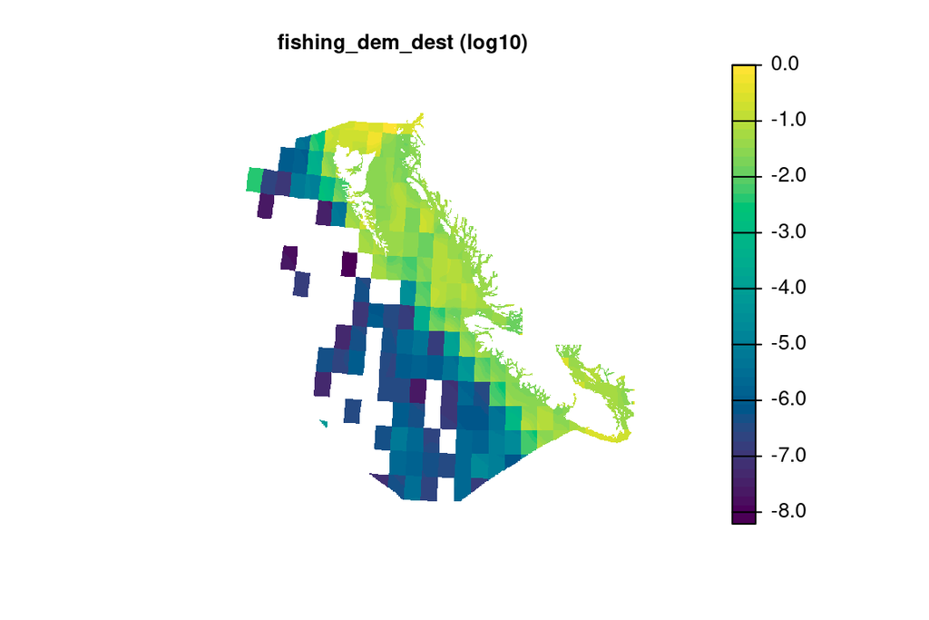

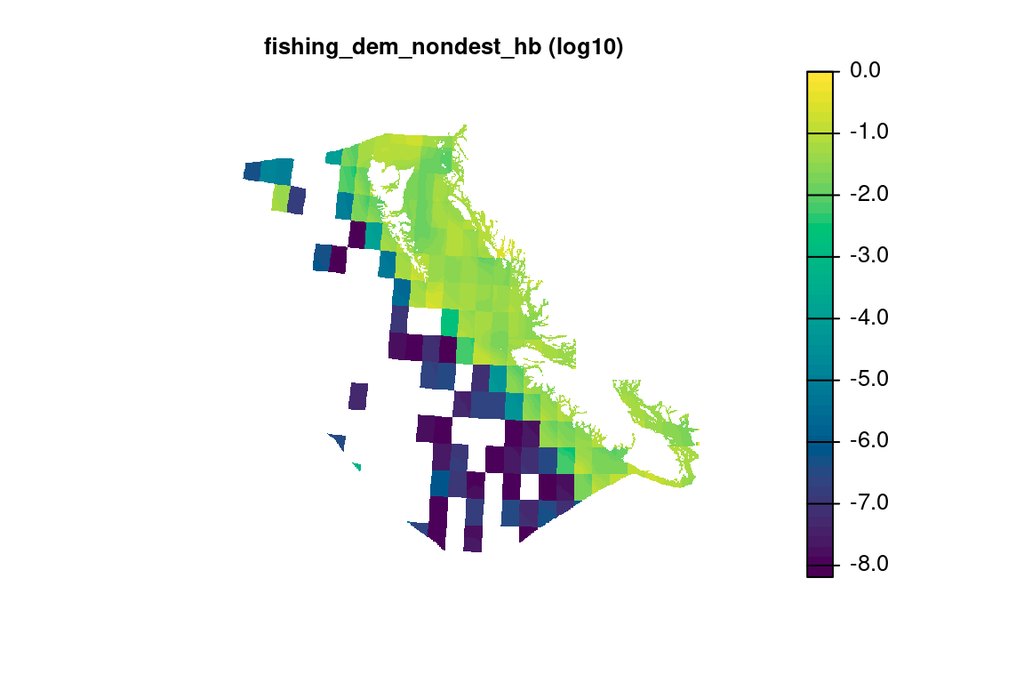

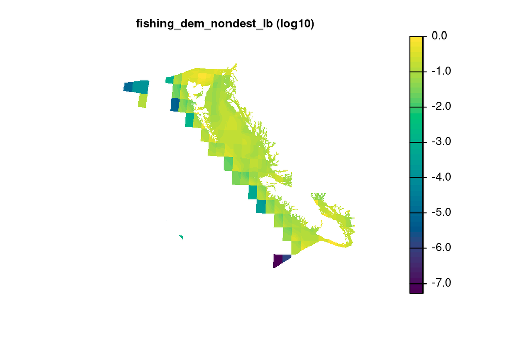

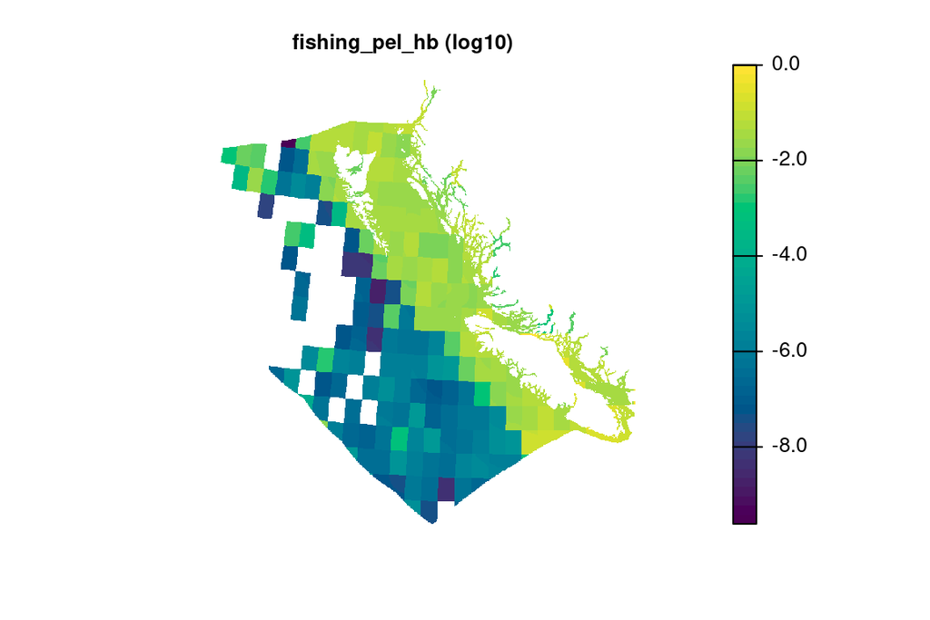

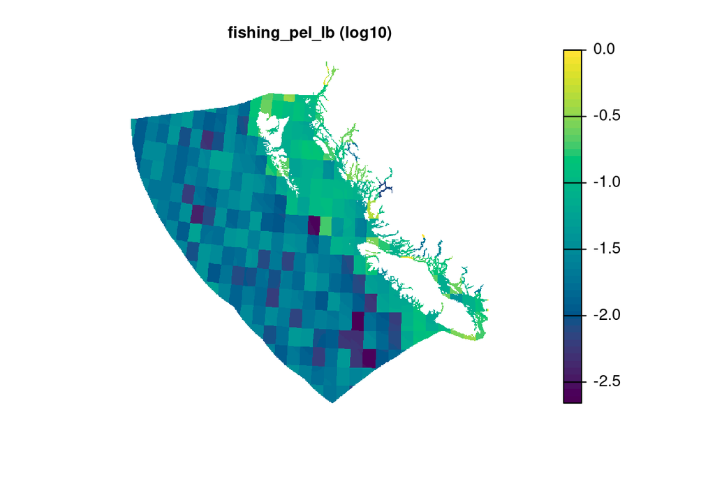

```r
stressor_map_fs <- list.files(here('_data/chi_halpern_2019/fishing_updated'),
                              pattern = 'fishing.+.tif',full.names = TRUE)

for(f in stressor_map_fs) { ### f <- stressor_map_fs[1]
  r <- rast(f)

  plot(log10(r), col = hcl.colors(n = 50), axes = FALSE,
       main = basename(f) %>% str_replace('.tif', ' (log10)'))
}
```